# ICE Annina 10x sequencing analysis - ML predictions of human data

Author

Vladyslav Korobeynyk at Jessberger/Robinsonlab, UZH

Published

August 13, 2026

**Note**

In this script we are building glmnet model using gene expression as covariate to model patient’s age

**What this script does:** loads the human metacell-level `SingleCellExperiment` objects and DEA tables produced by `01_human_Processing.qmd`/ `02_human_Analysis_metacell_Level.qmd`, then for each cell type (IN, EN) trains an lasso (glmnet, gaussian family) model that predicts chronological Age from metacell gene expression. Two evaluation strategies are used: (1) a standard 80/20 train/test split repeated across `n_times` random seeds, on all patients pooled together, and (2) a leave-several-patients-out scheme repeated across `n_times` random samples of held-out patients, to test how well the model generalizes to patients it never saw during training. For each strategy, predicted-vs-true-age plots, CV error plots, and gene coefficient tables/stability plots are produced and saved, to be compared later against the organoid-derived model.

- We apply 2 strategies. 1) Perform train/test split with all patient together and 2) Leave one patient out, train model on all other patients and test on left-out patient. The latter is to test generalizability of the model.
- For strategy #2 we perform model training/testing several times (according to param n_times) where the patients are randomly sampled.
- Gene selection for model is performed by taking genes present in at least 5% of metacells and with more than 10 counts

# Setup

```r
options(future.globals.maxSize = 8000 * 1024^2)
suppressMessages({
  library(scater)
  library(dplyr)
  library(caret)
  library(purrr)
  library(parallel)
  library(ggpubr)
  library(ggplot2)
  library(stringr)
  library(magrittr)
  library(glmnet)
  library(knitr)
  library(DT)
})
source(params$helper_functions_path)
dir.create(params$glmnet_output_dir, recursive = TRUE, showWarnings = FALSE)

set.seed(1)
n_times = params$n_times
```

# Load data and params

```r
# -----#
# IN
# -----#
metacell_sce_IN = readRDS(file.path(params$metacell_dir, "metacell_sce_IN_human.RDS"))
metadata_metacell_sce_IN = colData(metacell_sce_IN)
DEA_metacell_sce_IN = read.csv(file.path(params$dea_dir, "DEA_metacell_iN_old_vs_young.csv"), row.names = 1)

# -----#
# EN
# -----#
metacell_sce_EN = readRDS(file.path(params$metacell_dir, "metacell_sce_EN_human.RDS"))
metadata_metacell_sce_EN = colData(metacell_sce_EN)
DEA_metacell_sce_EN = read.csv(file.path(params$dea_dir, "DEA_metacell_exN_old_vs_young.csv"), row.names = 1)
```

# Helper functions

Both modelling strategies (all-patients 80/20 split, and leave-patients-out) are run identically for IN and EN.

```r
#' Keep genes expressed in at least min_fraction_metacells of metacells
#' Rationale: reduces noise/feature count before feeding into glmnet
filter_genes_min_expression = function(sce, min_count = params$min_gene_count,
                                        min_fraction_metacells = params$min_fraction_metacells_expressing) {
  keep = rowSums(counts(sce) >= min_count) >= (min_fraction_metacells * ncol(sce))
  sce[keep, ]
}

#' Predicted vs. true age scatter + regression line + R^2
#' color_by: optional column name in df to map to point color
plot_pred_vs_age = function(df, color_by = NULL, title = "Predicted vs chronological Age per cell") {
  if (is.null(color_by)) {
    p = ggplot(df, aes(x = chronological_age, y = pred)) +
      geom_point(color = "skyblue") +
      geom_smooth(method = "lm", color = "black", linetype = "dashed") +
      stat_regline_equation(aes(label = ..rr.label..), color = "black", show.legend = FALSE)
  } else {
    p = ggplot(df, aes(x = chronological_age, y = pred, color = .data[[color_by]])) +
      geom_point(size = 0.75) +
      geom_smooth(method = "lm", linetype = "dashed") + # one line per group (color inherited)
      stat_regline_equation(aes(label = ..rr.label..), show.legend = FALSE) # one R^2 per group, stacked automatically by ggpubr
  }
  p +
    labs(y = "Predicted Age", x = "True Age") +
    ggtitle(title) +
    theme_bw()
}

#' CV MSE across training seeds, with the mean test-set MSE.
plot_cv_mse_across_seeds = function(model_params_list, n_times, title = "MSE of CV") {
  df = lapply(model_params_list, function(x) x[c("lambda.min", "MSE_cv", "MSE_cv_sd", "seed", "MSE_test")]) %>%
    do.call(rbind.data.frame, .)

  summary_row = data.frame(
    lambda.min = mean(df$lambda.min),
    MSE_cv = mean(df$MSE_test),
    MSE_cv_sd = sd(df$MSE_test),
    seed = "test_data_acrossSeeds"
  )
  df = rbind(df %>% select(!MSE_test), summary_row)
  df$seed = factor(df$seed, levels = c(as.character(seq_len(n_times)), "test_data_acrossSeeds"))

  ggplot(df, aes(x = seed, y = MSE_cv, color = lambda.min)) +
    geom_point() +
    geom_errorbar(aes(ymin = MSE_cv - MSE_cv_sd, ymax = MSE_cv + MSE_cv_sd)) +
    ggtitle(title)
}

#' Strategy 1: train/test split with all patients pooled, repeated across n_times seeds
run_glmnet_allpatients = function(sce, n_times, label, output_dir) {

  sce = filter_genes_min_expression(sce)
  logcounts_df = as.data.frame(t(logcounts(sce)))
  logcounts_df$label = sce$Age
  meta = colData(sce)

  lst_predictions = train_glmnet_model(df = logcounts_df, model_family = "gaussian",
                                        metadata = meta, n_times = n_times)

  # Predicted vs true age
  df_pred = lapply(lst_predictions$lst, function(x) x$predictions[c("pred", "chronological_age")]) %>%
    do.call(rbind.data.frame, .)
  print(plot_pred_vs_age(df_pred))

  # CV error across seeds
  print(plot_cv_mse_across_seeds(lapply(lst_predictions$lst, `[[`, "model_params"), n_times))

  # MSE across lambdas (regularization path)
  plot(lst_predictions$cvfit)
  title(main = "lambda regularization vs MSE", line = 2.5)

  # Coefficients
  coefs = lapply(lst_predictions$lst, function(x) x$coeffs$gene_imp) %>%
    do.call(cbind.data.frame, .)
  colnames(coefs) = names(lst_predictions$lst)
  coefs = coefs[rowMeans(coefs) != 0, ] %>% mutate(mean = rowMeans(.))
  coefs = coefs[-1, ] %>% round(2)  # remove intercept

  print(datatable(coefs))
  write.table(coefs, file.path(output_dir, paste0("coefs_glmnet_human_", label, "_allPatientsTogether.txt")))

  # Predicted vs true age, colored by covariate
  df_pred_cov = lapply(lst_predictions$lst, function(x) {
    x$predictions[c("pred", "chronological_age", "sex", "diagnosis", "sample_source")]
  }) %>% do.call(rbind.data.frame, .)

  print(plot_pred_vs_age(df_pred_cov, color_by = "sex"))
  print(plot_pred_vs_age(df_pred_cov, color_by = "diagnosis"))
  print(plot_pred_vs_age(df_pred_cov, color_by = "sample_source"))

  invisible(list(coefs = coefs, predictions = lst_predictions))
}

#' Strategy 2: leave n_leftout patients out, train on the rest, predict the held-out
#' patients, repeated across n_times random samples of held-out patients
run_glmnet_leaveout = function(sce_full, n_times, n_leftout, label, output_dir,
                                DEA_table, top_n_genes) {

  lst_predictions_leftOutpatients = list()

  for (seed in seq_len(n_times)) {
    set.seed(seed)
    leftout_patient = sample(unique(sce_full$Individual_ID), n_leftout)
    rest_of_patients = setdiff(unique(sce_full$Individual_ID), leftout_patient)

    sce_train = sce_full[, sce_full$Individual_ID %in% rest_of_patients]
    sce_train = filter_genes_min_expression(sce_train)

    # Internal cross validation determines lambda and then we predict on the held-out patients.
    data = as.data.frame(t(logcounts(sce_train)))
    data$label = sce_train$Age

    out = train_glmnet_model(df = data, model_family = "gaussian", n_times = 1, test = FALSE)

    sce_test = sce_full[, sce_full$Individual_ID %in% leftout_patient]
    gene_cols = setdiff(colnames(data), "label")
    test_data = as.data.frame(t(logcounts(sce_test)[gene_cols, ]))
    test_label = sce_test$Age

    preds = predict(out$cvfit, newx = as.matrix(test_data), s = "lambda.min", type = "response")

    index_lambda = out$cvfit$index["min", ]
    seed_key = paste0("seed_", seed)
    lst_predictions_leftOutpatients[[seed_key]] = list(
      model_params = list(
        lambda.min = out$cvfit$lambda.min,
        MSE_cv = out$cvfit$cvm[index_lambda],
        MSE_cv_sd = out$cvfit$cvsd[index_lambda],
        seed = seed,
        MSE_test = ModelMetrics::mse(test_label, preds[, 1])
      ),
      coeffs = list(
        gene_imp = coef(out$cvfit) %>% as.matrix() %>% as.data.frame() %>% round(3) %>%
          mutate(gene = rownames(.))
      ),
      predictions = data.frame(
        pred = preds[, 1],
        chronological_age = test_label,
        seed = seed_key,
        leftOut_patient = leftout_patient,
        diagnosis = sce_test$Diagnosis,
        Sample_Source = sce_test$Sample_Source,
        sex = sce_test$Sex
      )
    )
  }

  # Predicted vs true age
  df_pred = lapply(lst_predictions_leftOutpatients, function(x) {
    x$predictions[c("pred", "chronological_age", "diagnosis", "Sample_Source", "sex")]
  }) %>% do.call(rbind.data.frame, .)

  print(plot_pred_vs_age(df_pred))
  print(plot_pred_vs_age(df_pred, color_by = "sex"))
  print(plot_pred_vs_age(df_pred, color_by = "diagnosis"))
  print(plot_pred_vs_age(df_pred, color_by = "Sample_Source"))

  # CV error across seeds
  print(plot_cv_mse_across_seeds(
    lapply(lst_predictions_leftOutpatients, `[[`, "model_params"), n_times
  ))

  # Coefficients: full_join across seeds since gene sets can differ between seeds
  coefs = lapply(lst_predictions_leftOutpatients, function(x) x$coeffs$gene_imp)
  coefs = Reduce(function(x, y) full_join(x, y, by = "gene"), coefs)
  genenames = coefs$gene
  coefs = coefs %>% select(!gene)
  coefs[is.na(coefs)] = 0
  rownames(coefs) = genenames
  colnames(coefs) = names(lst_predictions_leftOutpatients)
  coefs = coefs[rowMeans(coefs) != 0, ] %>% mutate(mean = rowMeans(.))
  coefs = coefs[-1, ] %>% round(2)  # remove intercept

  write.table(coefs, file.path(output_dir, paste0("coefs_glmnet_human_", label, "_leftOutPatients.txt")))

  # Feature stability across seeds: how often + how strongly each gene was selected
  coef_df = coefs %>% select(-mean)
  summary_df = data.frame(
    gene = rownames(coef_df),
    selection_freq = rowSums(coef_df != 0),
    mean_coef = rowMeans(coef_df),
    sd_coef = apply(coef_df, 1, sd)
  ) %>%
    filter(selection_freq >= 10) %>%
    arrange(desc(selection_freq), desc(abs(mean_coef))) %>%
    slice_head(n = 50)

  print(
    ggplot(summary_df, aes(x = reorder(gene, mean_coef), y = mean_coef)) +
      geom_errorbar(aes(ymin = mean_coef - sd_coef, ymax = mean_coef + sd_coef),
                    width = 0.2, color = "gray60", alpha = 0.7) +
      geom_point(color = "gray20", size = 2.5) +
      coord_flip() +
      theme_minimal() +
      labs(
        title = paste0("Feature Stability across ", n_times, " Seeds"),
        subtitle = "Top genes ranked by Selection Frequency and Coefficient",
        x = "Gene", y = "Average Coefficient"
      )
  )

  # Expression of top up/down genes across Age, by a few covariates
  genes = c(
    coefs %>% arrange(mean) %>% slice(1:top_n_genes) %>% rownames(),
    coefs %>% arrange(desc(mean)) %>% slice(1:top_n_genes) %>% rownames()
  )

  print(
    plotExpression(sce_full, features = genes, x = "Age", ncol = 4, colour_by = "Sample_Source") +
      geom_smooth(method = "lm")
  )
  print(datatable(DEA_table[genes, ] %>% select(-gene) %>% round(4)))

  print(
    plotExpression(sce_full, features = genes, x = "Age", ncol = 4, colour_by = "Sex") +
      geom_smooth(method = "lm")
  )
  print(
    plotExpression(sce_full, features = genes, x = "Age", ncol = 4, colour_by = "Diagnosis") +
      geom_smooth(method = "lm")
  )

  invisible(list(coefs = coefs, predictions = lst_predictions_leftOutpatients))
}
```

# Modelling all patients together

**IN**

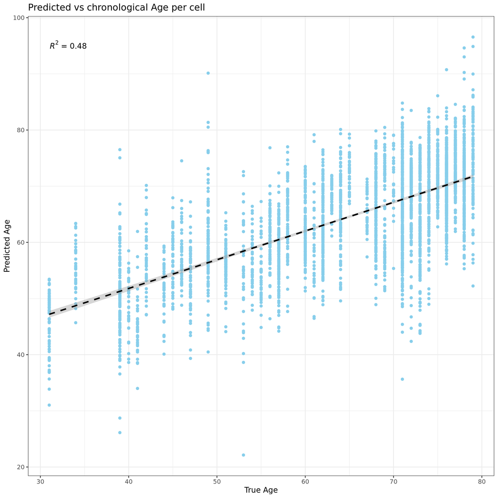

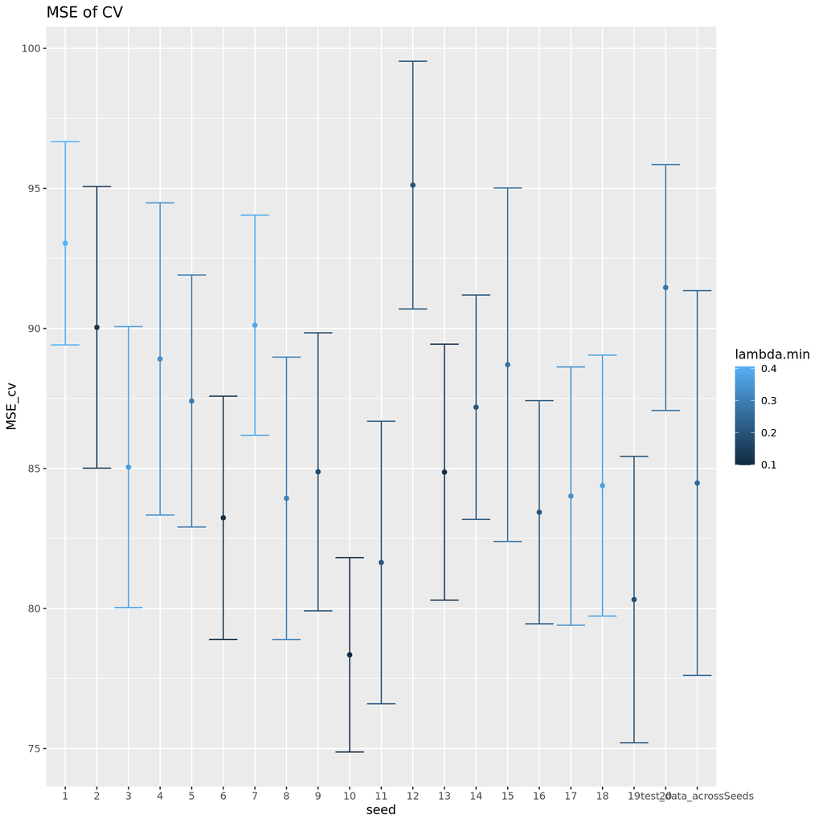

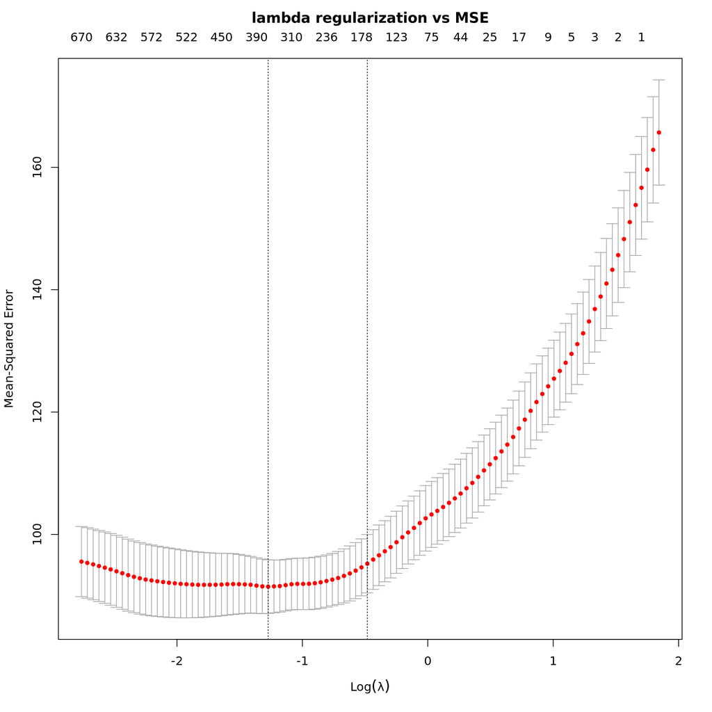

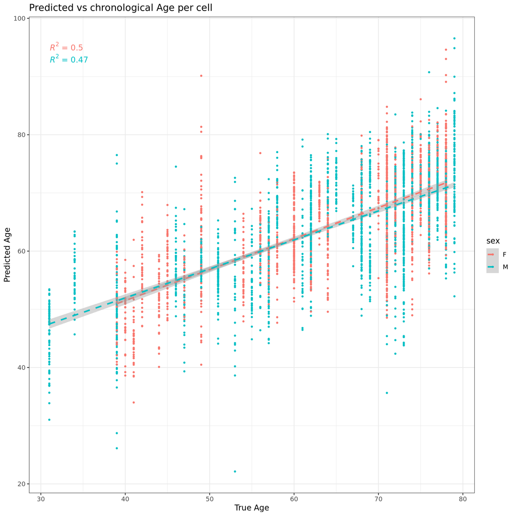

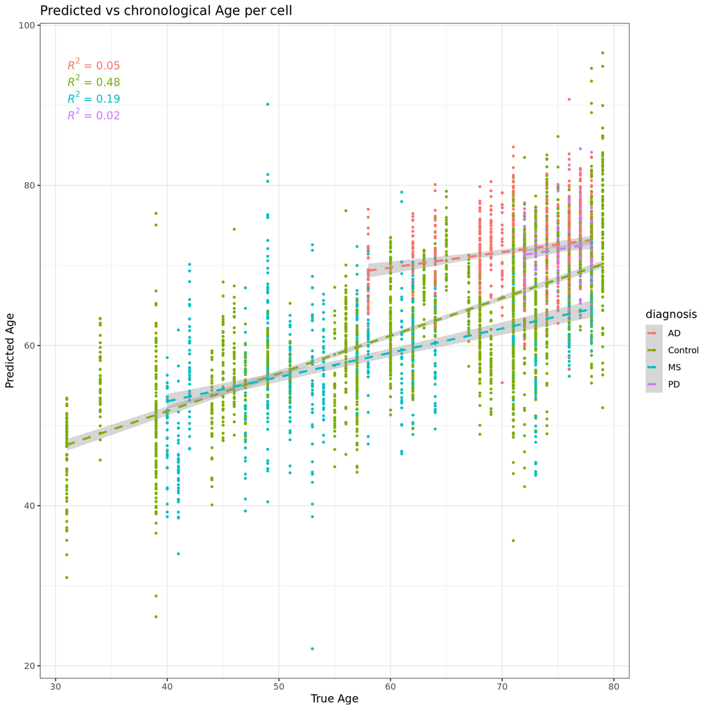

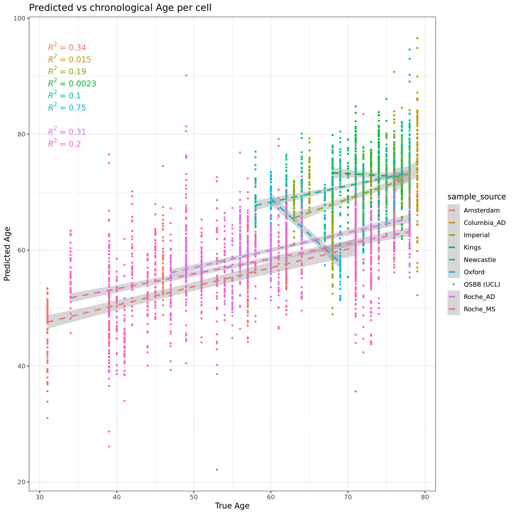

```r
result_allpatients_IN = run_glmnet_allpatients(
  sce = metacell_sce_IN, n_times = n_times, label = "IN", output_dir = params$glmnet_output_dir
)
```

**EN**

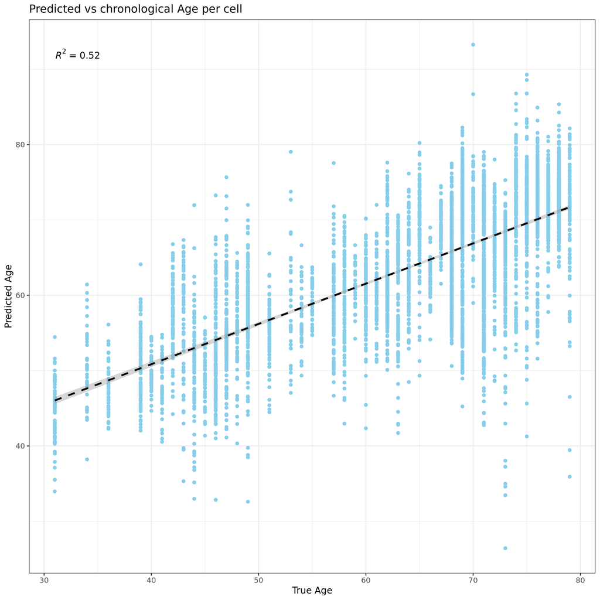

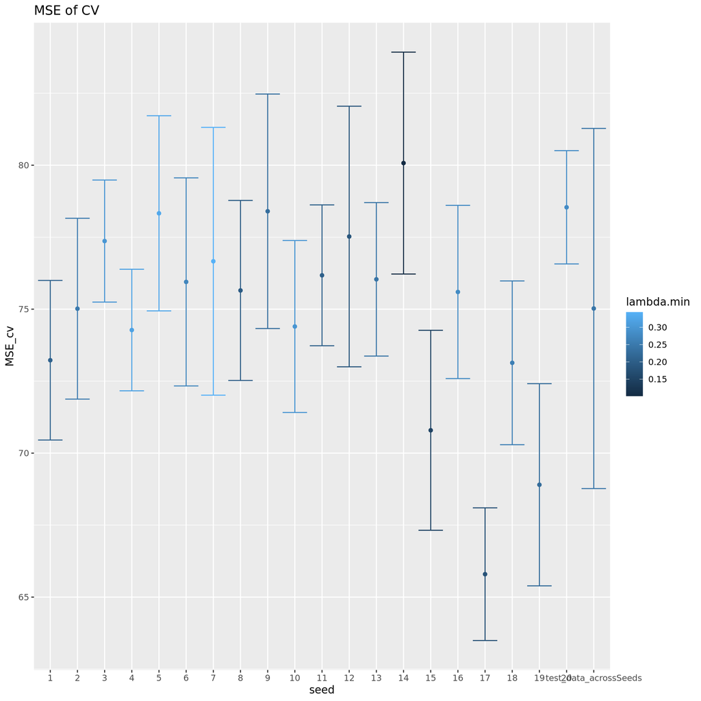

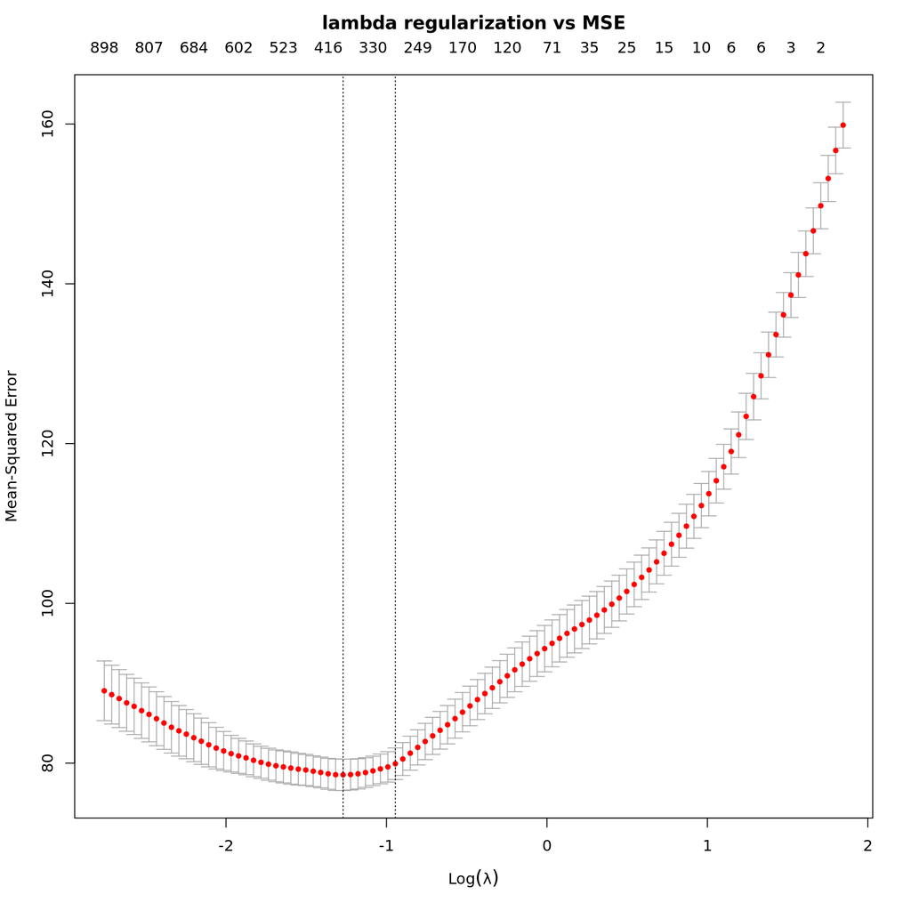

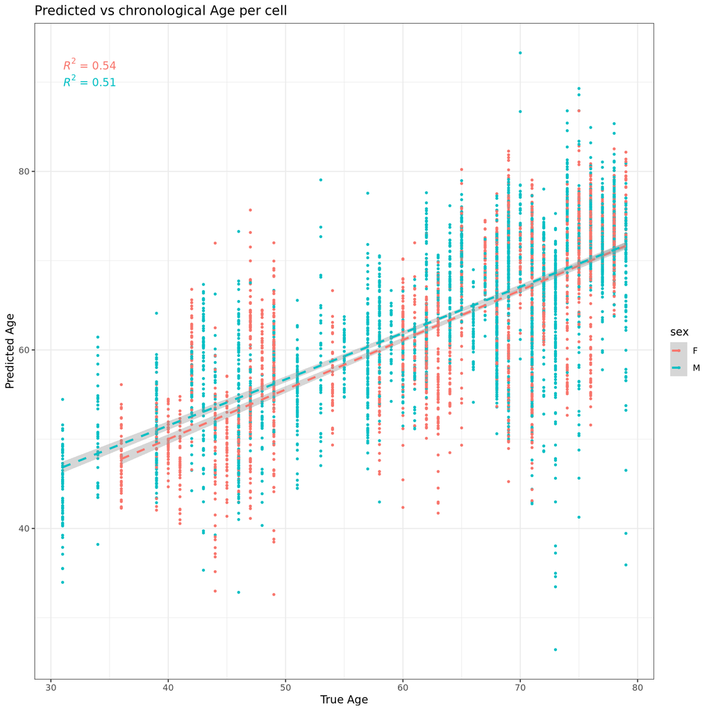

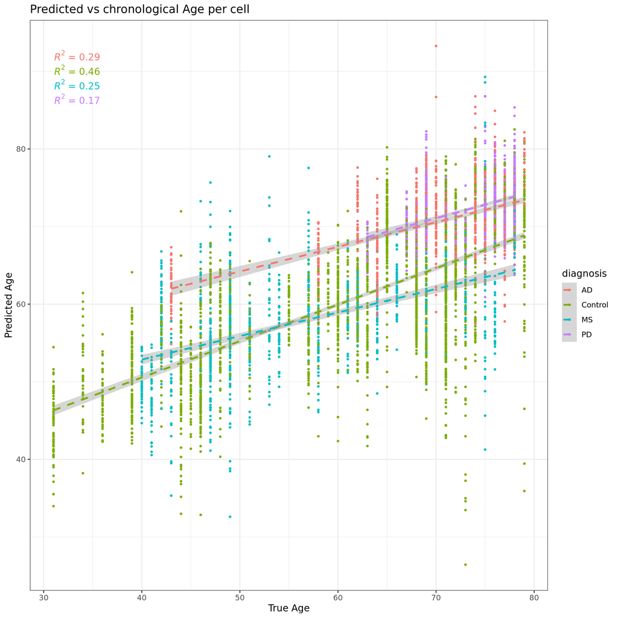

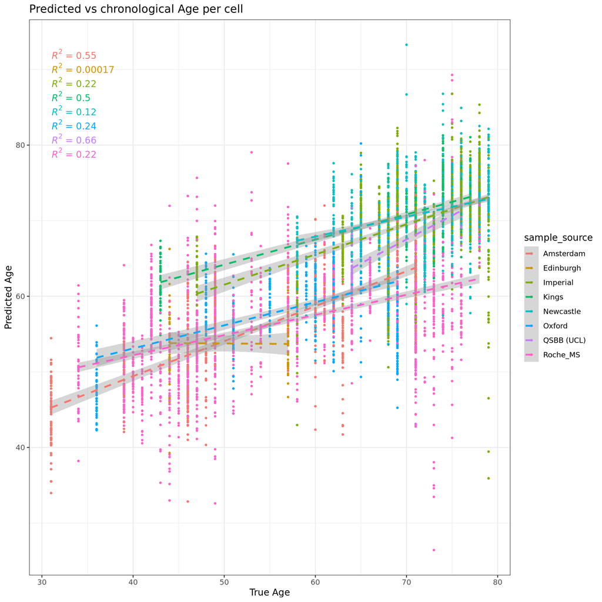

```r
result_allpatients_EN = run_glmnet_allpatients(
  sce = metacell_sce_EN, n_times = n_times, label = "EN", output_dir = params$glmnet_output_dir
)
```

# Generalizability to new patients

**IN**

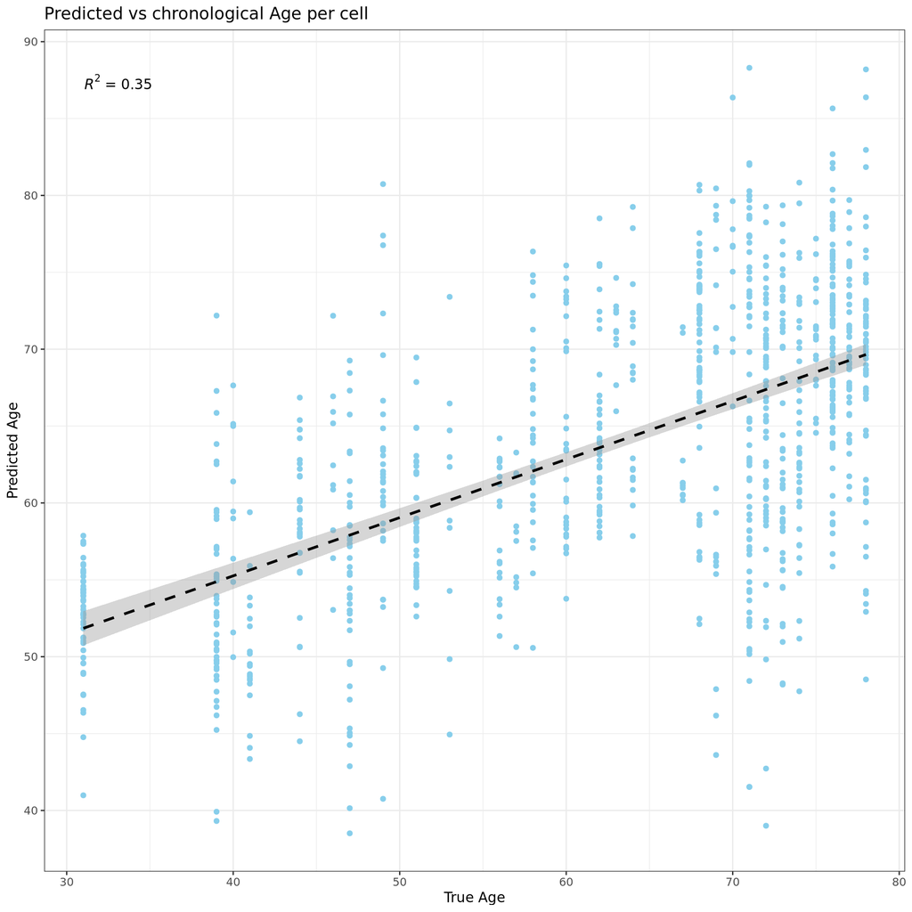

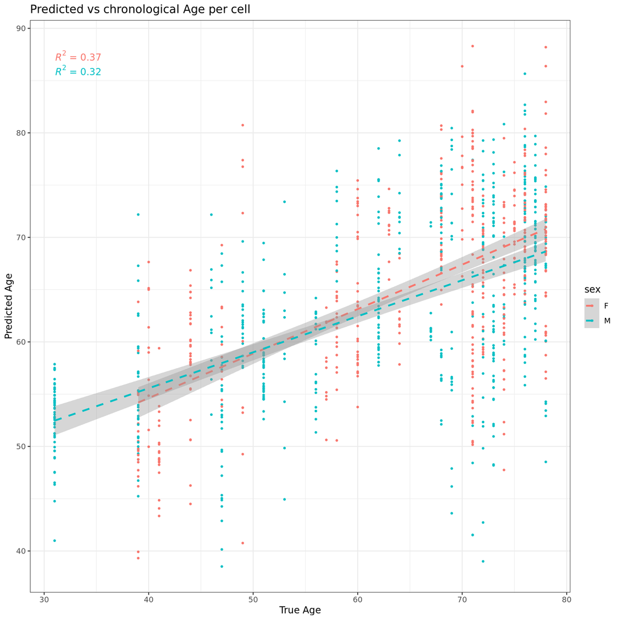

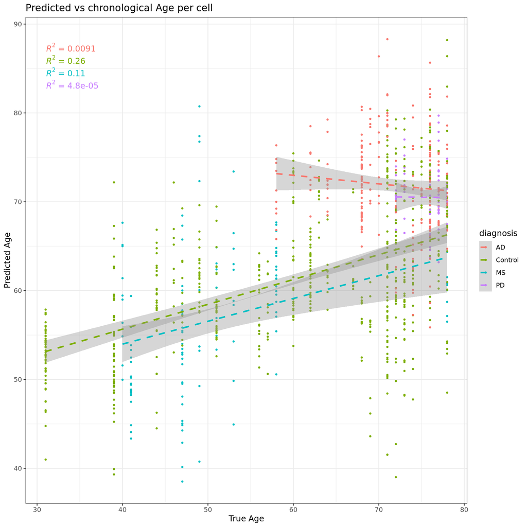

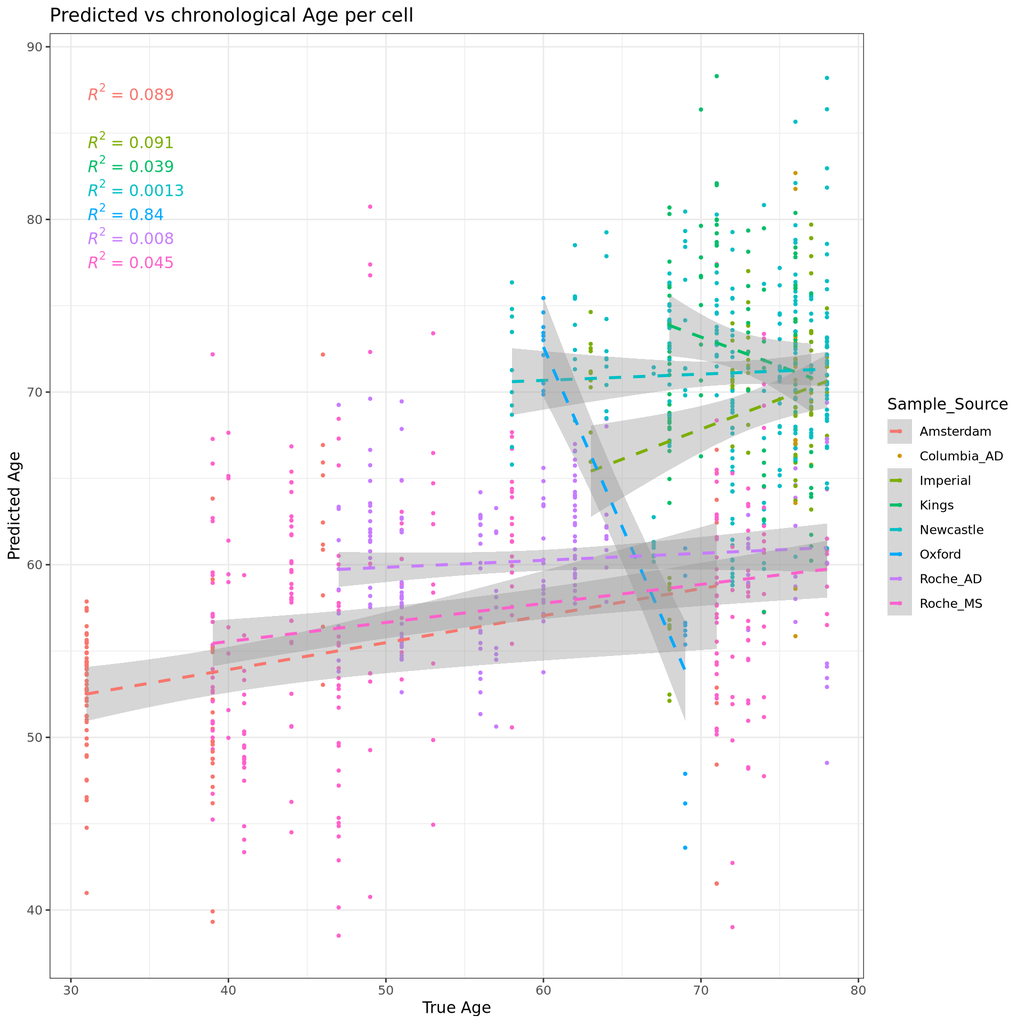

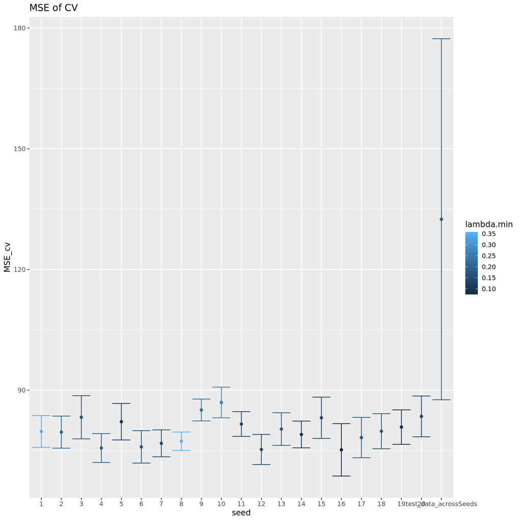

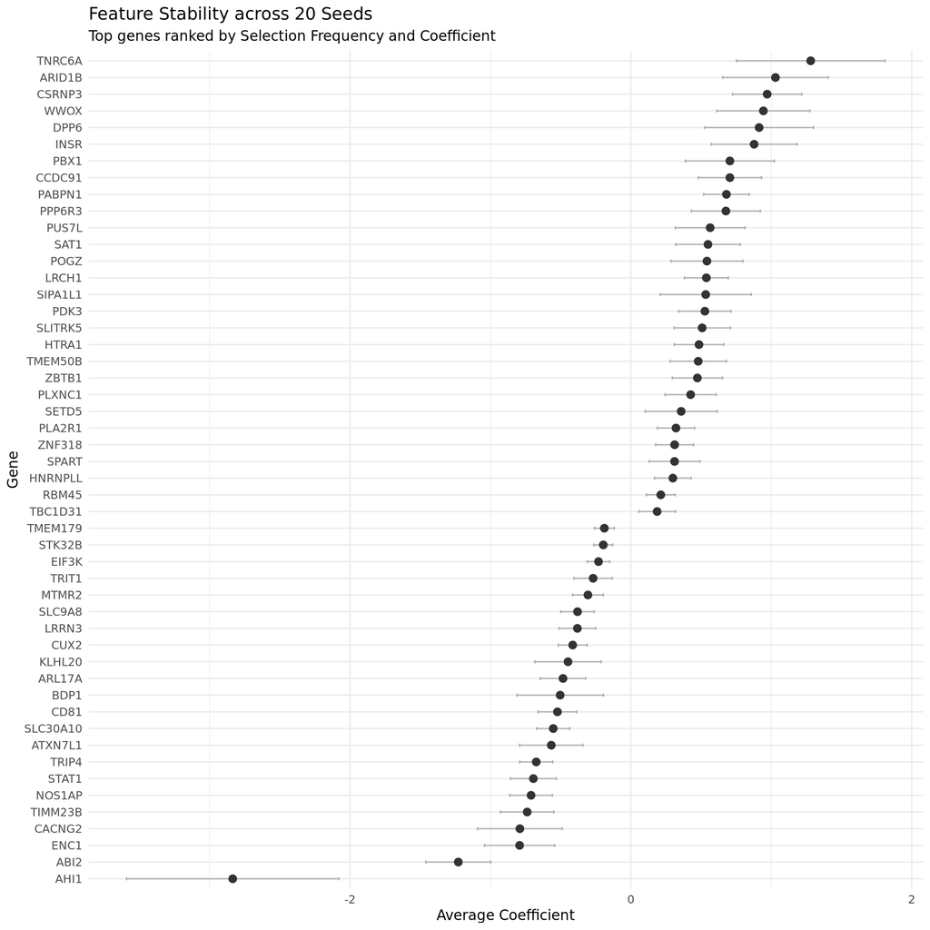

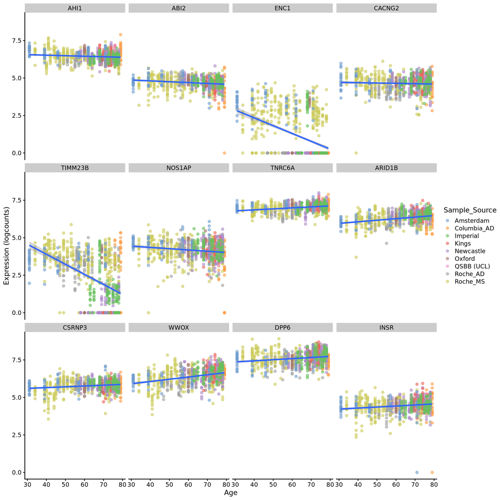

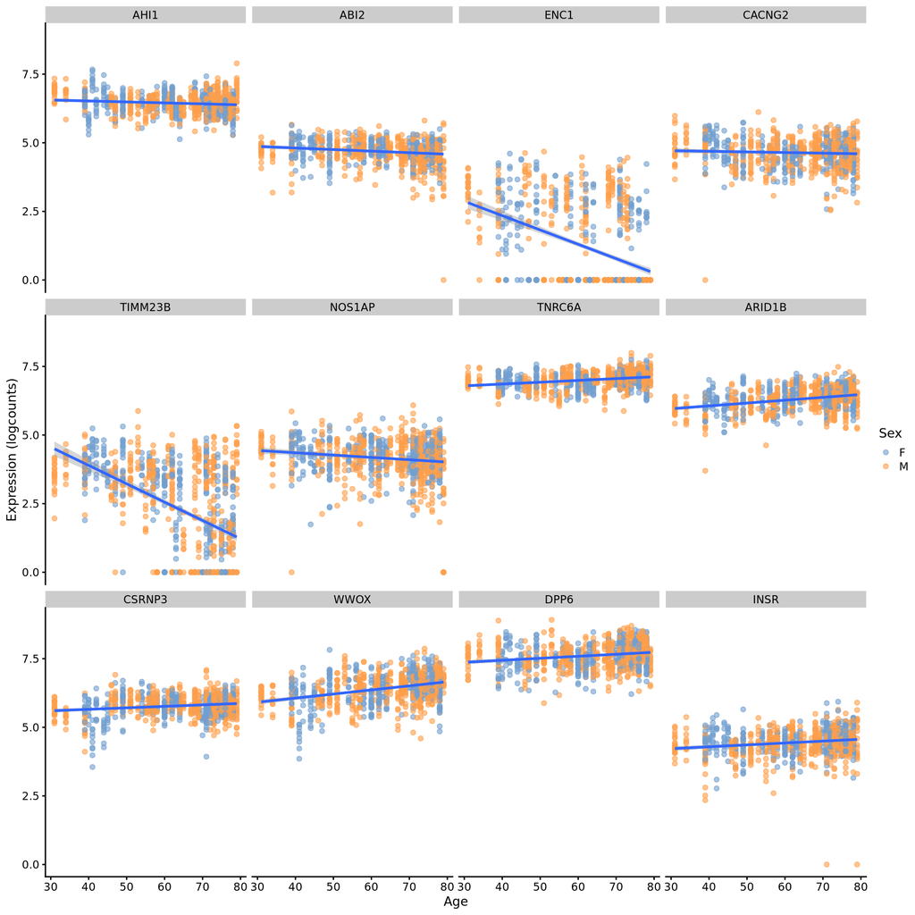

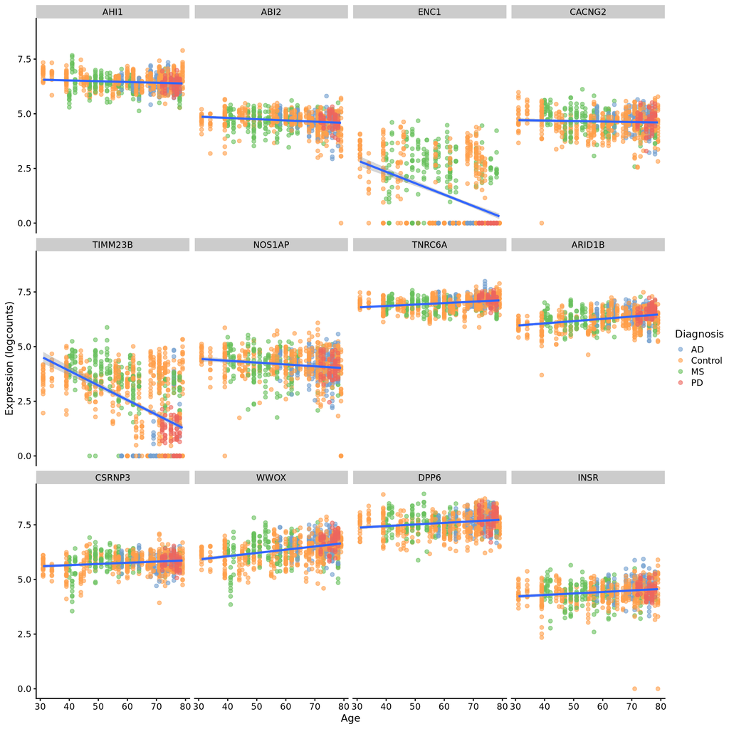

```r
result_leaveout_IN = run_glmnet_leaveout(
  sce_full = metacell_sce_IN, n_times = n_times, n_leftout = params$n_leftout_patients,
  label = "IN", output_dir = params$glmnet_output_dir,
  DEA_table = DEA_metacell_sce_IN, top_n_genes = params$top_n_genes_for_expression_plots
)
```

**EN**

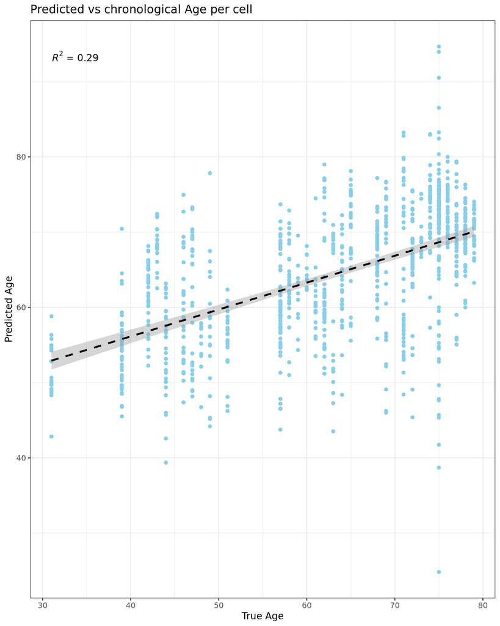

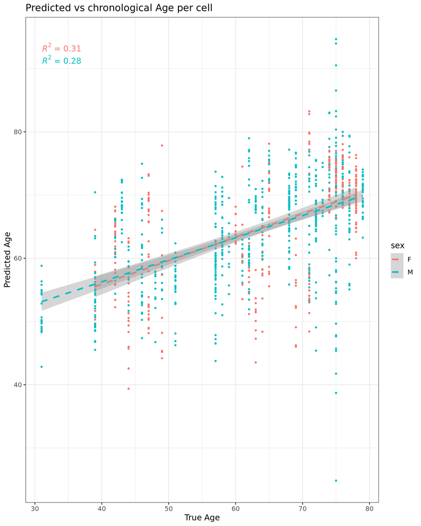

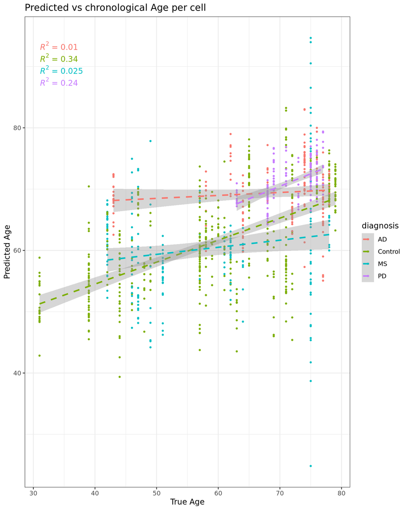

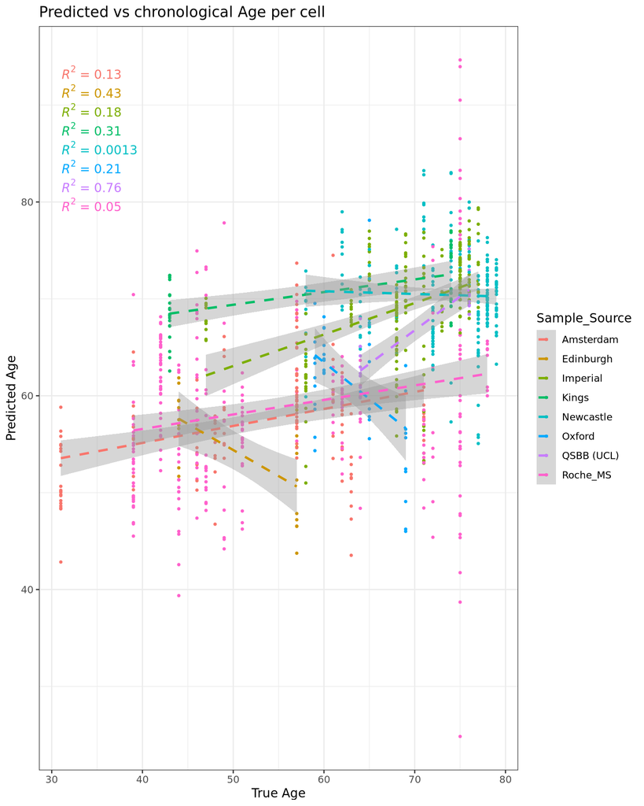

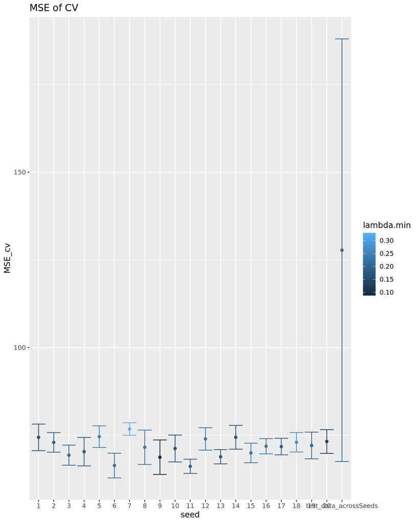

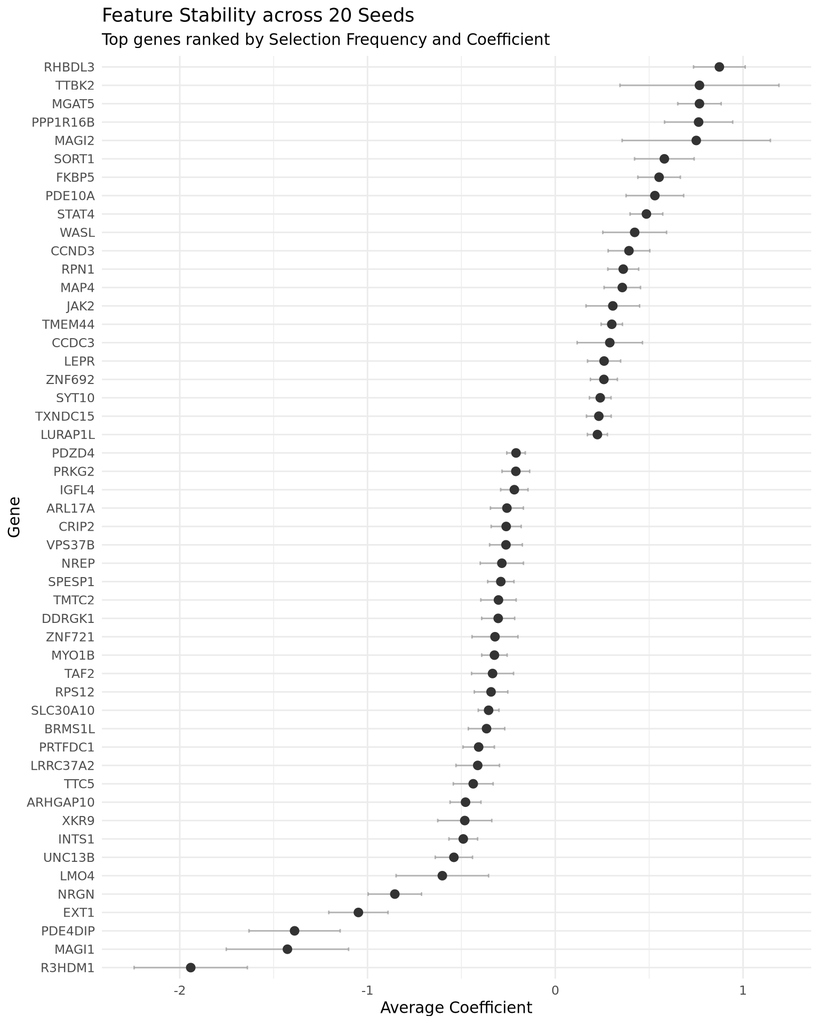

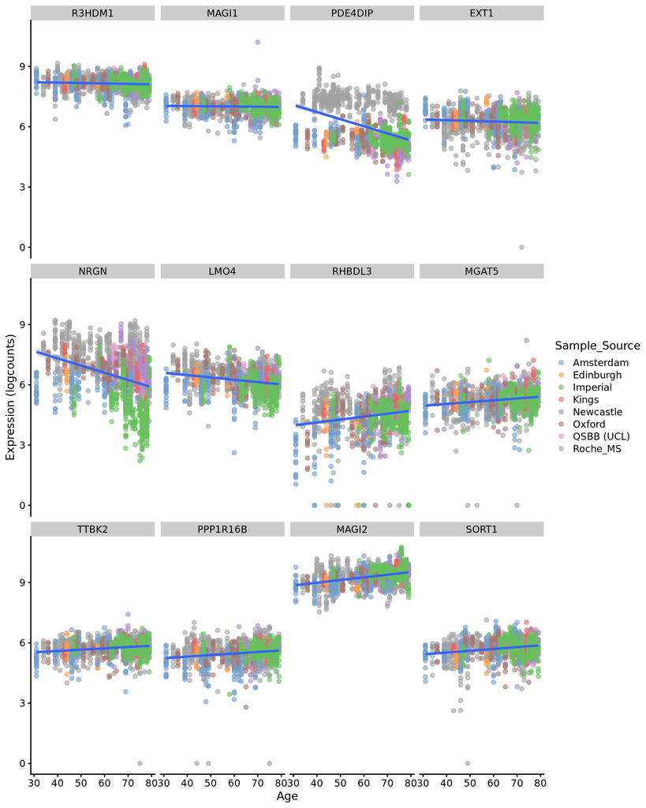

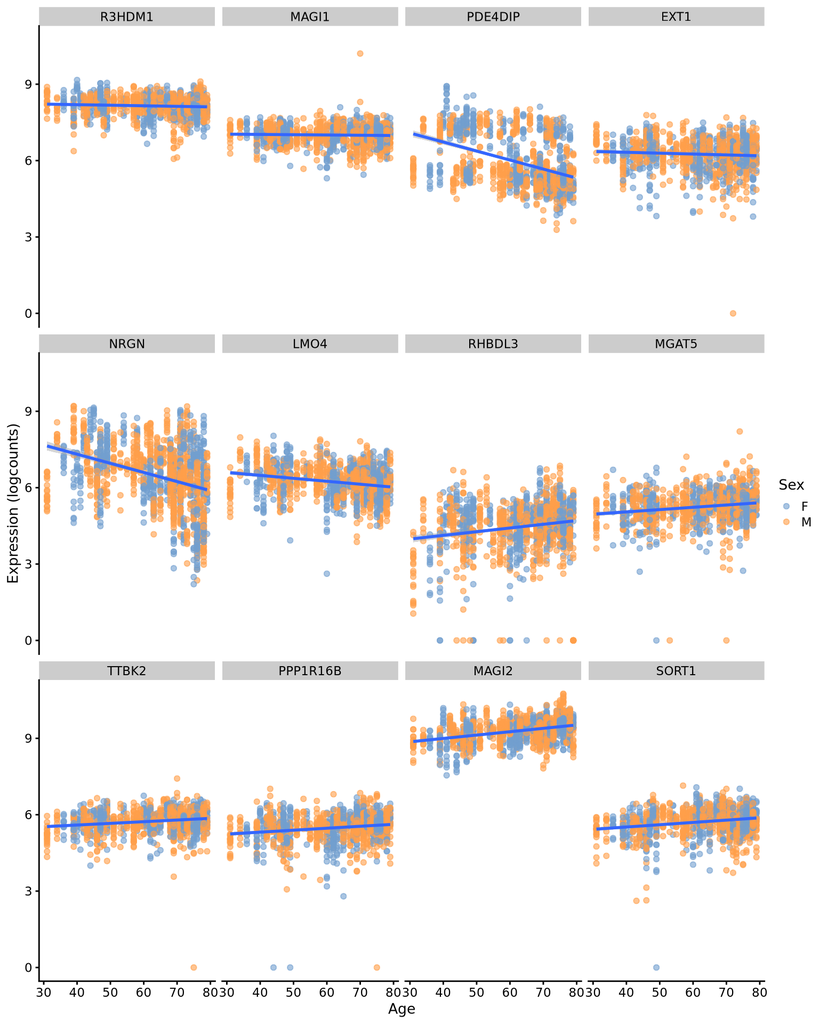

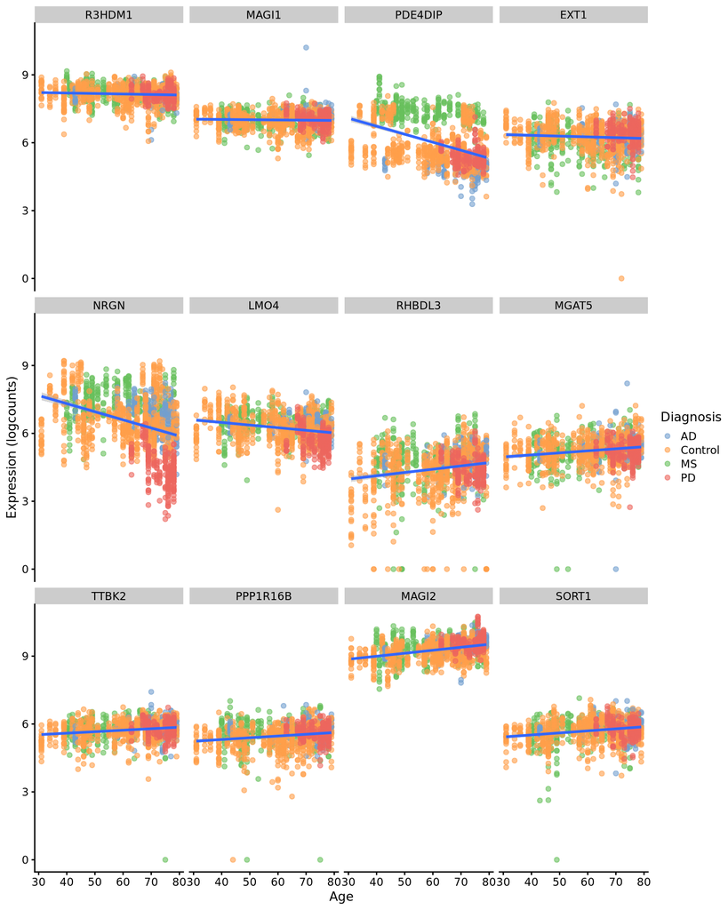

```r
result_leaveout_EN = run_glmnet_leaveout(
  sce_full = metacell_sce_EN, n_times = n_times, n_leftout = params$n_leftout_patients,
  label = "Excitatory_Neurons", output_dir = params$glmnet_output_dir,
  DEA_table = DEA_metacell_sce_EN, top_n_genes = params$top_n_genes_for_expression_plots
)
```